# Developing Data Products - Course Project

25th October 2019

## Introduction

Have you ever wondered how diamonds are priced beyond the number of carats(or weight)? Price also depends on the diamond's cut, color, and clarity.

- Cut: quality of the diamond from best to worst (Ideal, Premium, Very Good, Good, Fair)
- Color: best(D) to worst(J)
- Clarity: measures how clear the diamond is from best to worst (IF, VVS2, VVS1, VS2, VS1, SI2, SI1, I1)

## Steps involved in the working of the App

This shiny app will predict diamond price based on your input of these factors.

- Essentially for a given input of cut, color and clarity all the data points corresponding to them are extracted from the data set "diamonds"
- Thereafter a model is trained with Price as output and Carat as input for the subsetted data.
- Once the Model is trained user can give carat of diamond as input for which the predicted price will be displayed. A demonstration has been given in later slides.

## Documentation

Here is a summary of the "diamonds" dataset found in the ggplot2 R package. As you can see, the factors were measured in over 50,000 diamonds

```r
summary(diamonds[,c(1:4,7)])
```

```
##      carat               cut        color        clarity
##  Min.   :0.2000   Fair     : 1610   D: 6775   SI1    :13065
##  1st Qu.:0.4000   Good     : 4906   E: 9797   VS2    :12258
##  Median :0.7000   Very Good:12082   F: 9542   SI2    : 9194
##  Mean   :0.7979   Premium  :13791   G:11292   VS1    : 8171
##  3rd Qu.:1.0400   Ideal    :21551   H: 8304   VVS2   : 5066
##  Max.   :5.0100                     I: 5422   VVS1   : 3655
##                                     J: 2808   (Other): 2531
##      price
##  Min.   :  326
##  1st Qu.:  950
##  Median : 2401
##  Mean   : 3933
##  3rd Qu.: 5324
##  Max.   :18823
##
```

## Summary plot of diamond data with each of the variables plotted against each other

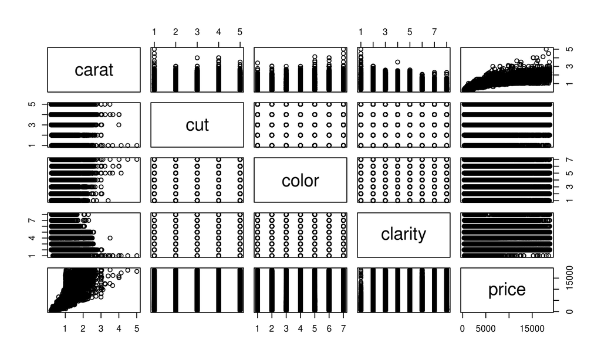

## A simple Demonstration of the App

- We subset data for cut = "Very Good", color = " F" and clarity = "IF".

```r
diamond_subset <-subset(diamonds, cut == "Very Good" & color == "F"
                        & clarity == "IF")
```

- We then train this sub-dataset for Price ~ Carat

```r
fit <- lm(price~carat,data = diamond_subset)
```

- We next predict the price of diamond using the trained model for a carat value of 3.4

```r
predict(fit,data.frame(carat=3.4))
```

```
##        1
## 43093.09
```

## Links

The Shiny app and source code can be reached at:

- **shiny app**: https://yash-jain.shinyapps.io/Project_App/
- **source code**: https://github.com/yash7798/Developing-Data-Products-Course-Project